# Spectogram_audio_updated

[figure not shown]

```python
import numpy as np
import matplotlib.pyplot as plt
import wave
import matplotlib.image as mpimg
import numpy.linalg as la
import os
import sys
import math
```

```python
# It's a function for the reading the audio file.

def readWavFile(filename):
    audio  = wave.open(filename,'r')
    sample_frequecny=audio.getframerate()
    total_samples=audio.getnframes()

    signal = audio.readframes(-1)
    signal = np.frombuffer(signal,'int16')
    signal = np.asarray(signal,dtype='double')
    audio_time=total_samples/sample_frequecny
    print('sample frequency:',sample_frequecny)
    print('total samples',total_samples)
    print('total time of the audio:'+str(audio_time)+" seconds")
    audio.close()
    return signal, sample_frequecny,total_samples

# it's function for the plotting the audio.
def plotAudio(data,title='title'):
    fig, ax = plt.subplots()
    #ax.plot(t, s)
    ax.plot(data)
    ax.set(xlabel='samples', ylabel='Signal', title=title)
    ax.grid()
    fig.savefig(title+".png")
    plt.show()


# it is giving the window of the audio file.
def get_window(audio,window_size,hop_index,hop_length):
    lower=hop_index*hop_length
    upper=lower+window_size
    return audio[lower:upper]

# converting the sample_window to vector
def convert_sample_window_to_vector(window_sample):
    output=np.fft.fft(window_sample,256)
    return np.log(np.abs(output[0:128]))


def get_spectrogram_vector(audio_file_path,window_type,window_size,hop_length):

    audio1, sample_frequency, total_samples = readWavFile(audio_file_path)
    total_hops=math.floor((total_samples-window_size)/hop_length+1)
    window=np.ones(window_size)
    if(window_type=='hamming'):
        window=np.hamming(window_size)
        print('\nusing hamming window')

    total_hops=math.floor((total_samples-window_size)/hop_length+1)
    spectrogram_vector=[]
    for hop_index in range(total_hops):
        sample_window=get_window(audio1, window_size, hop_index, hop_length)
        sample_window=np.multiply(sample_window,window)
        feature_vector=convert_sample_window_to_vector(sample_window)
        spectrogram_vector.append(feature_vector)
    spectrogram_vector=np.array(spectrogram_vector)


    return spectrogram_vector

def whitening(X):
    X_mean=np.mean(X,axis=0)
    X_centred=X-X_mean
    #print(np.mean(X_centred))
    L,U=np.linalg.eigh((1/N)*(X_centred.T@X_centred))
    idx = np.argsort(-L)
    L = L[idx]
    U = U[:,idx]
    L_sqrt=np.diag(np.sqrt(1/L))
    transformed_data=X_centred@U
    Y=transformed_data@L_sqrt
    return Y,L,U

def plot_audio_spectrogram(audio_feature_vector,title):
    N=audio_feature_vector.shape[0]
    fig=plt.figure(figsize=(20,20))
    plt.imshow(clean_audio_feature_vector.T)
    plt.title(title)
    plt.xlabel('Hop index')
    plt.ylabel('Frequencies')
```

```python
def cov_matrix(X):
    X_mean=np.mean(X,axis=0)
    X_centred=X-X_mean
    return ((1/N)*(X_centred.T@X_centred))
```

```python
def avg_non_digonal_entry(cov_mat):
    diag_cov_mat=np.diag(cov_mat)
    diag_cov_mat=np.diag(diag_cov_mat)
    cov_mat_without_digonal=cov_mat-diag_cov_mat

    avg_non_digonal_entry=(1/(N-1))*(1/(N-1))*np.sum(np.abs(cov_mat_without_digonal))
    #print(np.diag(cov_mat_without_digonal).shape)
    #print(np.sum(cov_mat_without_digonal))
    #print('avg_non_digonal_entry',avg_non_digonal_entry)
    return avg_non_digonal_entry
```

```
sample frequency: 16000
total samples 50000
total time of the audio:3.125 seconds
```

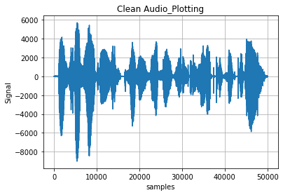

```
sample frequency: 16000
total samples 50000
total time of the audio:3.125 seconds
```

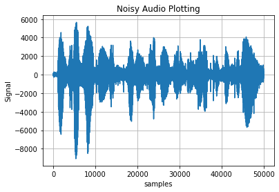

```python
# it's a 3.125 seconds audio file.
# it's frequecy is 16000 samples/second
# it's having 50,000 samples totally.
clean_audio_file_path='speech/speechFiles/clean.wav'

noisy_audio_file_path='speech/speechFiles/noisy.wav'

clean_audio, clean_audio_sample_frequency, clean_audio_total_samples = readWavFile(clean_audio_file_path)
plotAudio(clean_audio,'Clean Audio_Plotting')

noisy_audio1, noisy_audio1_sample_frequency, noisy_audio1_total_samples = readWavFile(noisy_audio_file_path)
plotAudio(noisy_audio1,'Noisy Audio Plotting')
```

Sample frequncy of the audio file is:$16 KHz$.

Winow size is:25 ms=25*16=400 samples.

shift(Hop length) is:10 ms=10*16=160 samples.

```python
window_type='hamming'
window_size=400
hop_length=160
hop_index=10
```

```
sample frequency: 16000
total samples 50000
total time of the audio:3.125 seconds

using hamming window
sample frequency: 16000
total samples 50000
total time of the audio:3.125 seconds

using hamming window
```

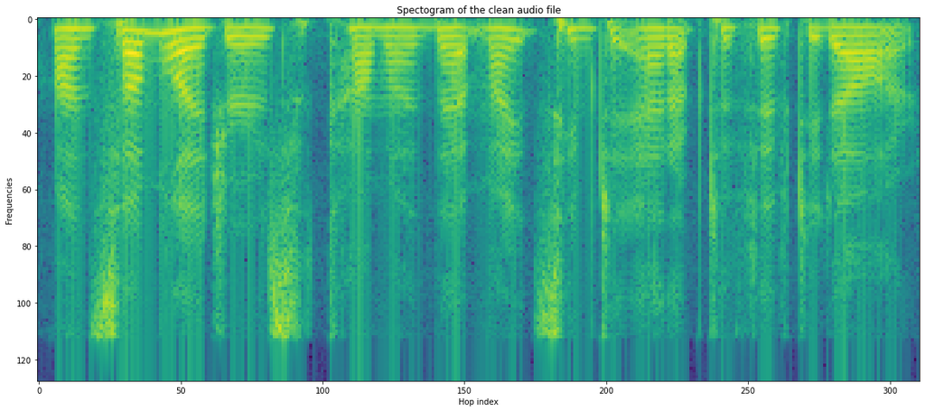

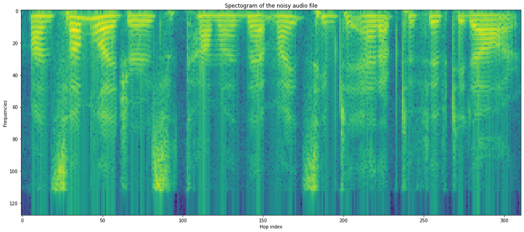

```python
clean_audio_feature_vector=get_spectrogram_vector(clean_audio_file_path,
                                                  window_type,
                                                  window_size,
                                                  hop_length)
N=clean_audio_feature_vector.shape[0]
plot_audio_spectrogram(clean_audio_feature_vector,'Spectogram of the clean audio file')

noisy_audio_feature_vector=get_spectrogram_vector(noisy_audio_file_path,
                                                  window_type,
                                                  window_size,
                                                  hop_length)
N=noisy_audio_feature_vector.shape[0]
plot_audio_spectrogram(noisy_audio_feature_vector,'Spectogram of the noisy audio file')
```

# Whitening tranformation of the Clean audio file

```
avg_non_digonal_entry of clean audio 8.748253883008567e-16
```

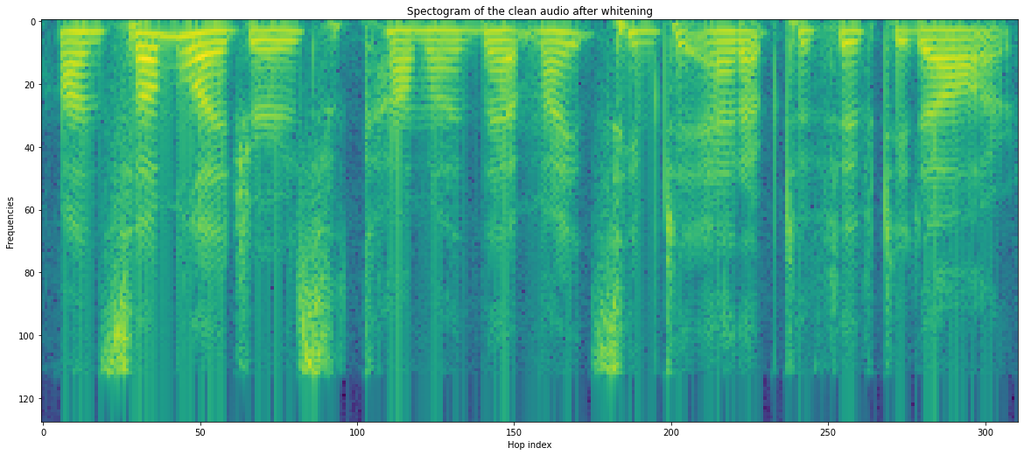

```python
clean_audio_Y,clean_audio_L,clean_audio_U=whitening(clean_audio_feature_vector)
clean_audio_cov_mat=(1/N)*clean_audio_Y.T@clean_audio_Y
print('avg_non_digonal_entry of clean audio',avg_non_digonal_entry(clean_audio_cov_mat))
plot_audio_spectrogram(clean_audio_Y,'Spectogram of the clean audio after whitening')
```

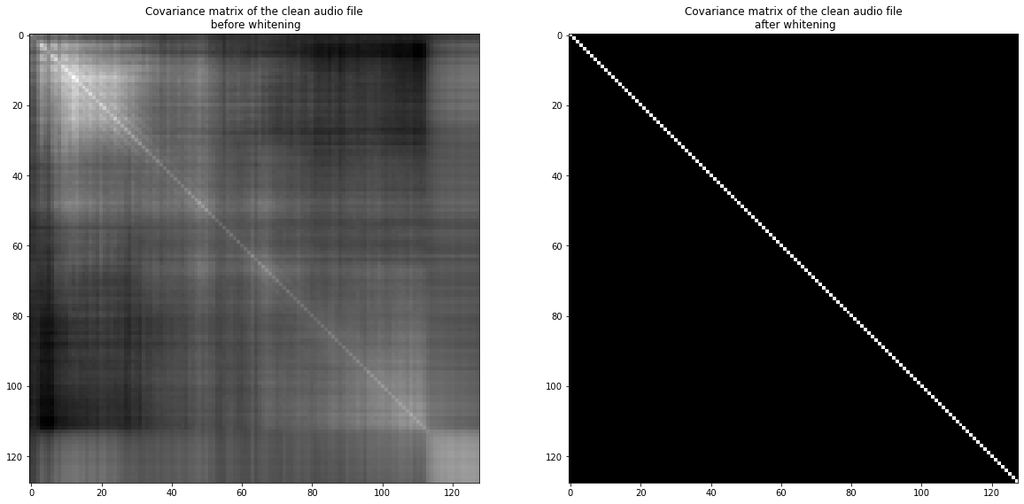

```python
fig=plt.figure(figsize=(20,20))

plot=fig.add_subplot(1,2,1)
plt.imshow(cov_matrix(clean_audio_feature_vector),cmap='gray')
plot.set_title('Covariance matrix of the clean audio file\n before whitening')
plot=fig.add_subplot(1,2,2)
plt.imshow(clean_audio_cov_mat,cmap='gray')
plot.set_title('Covariance matrix of the clean audio file\n after whitening',)
```

We can see the differences between the above two co-variance matrix plottings.

After whitening, the co-variance matrix of clean audio is identity matrix and all the non-digonal entries are almost zero.

The average absoulte value of the non digonal entry for clean audio is: 8.748253883008567e-16

# we use the whitening tranformation of the clean audio file to whitening the noisy audio

```
we use the whitening tranformation of the clean audio file to whitening the noisy audio

avg_non_digonal_entry of noisy audio 0.025820938343077755
```

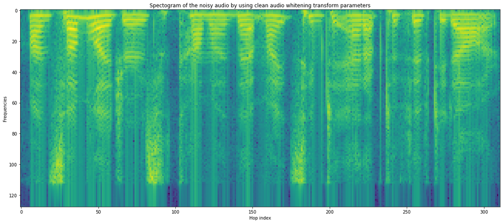

```python
# appling that transform on the noise image

# data centering on noisy data.
noisy_audio_centred=noisy_audio_feature_vector-np.mean(noisy_audio_feature_vector,axis=0)
clean_audio_L_sqrt=np.diag(np.sqrt(1/clean_audio_L))
transformed_data=noisy_audio_centred@clean_audio_U
noisy_audio_Y=transformed_data@clean_audio_L_sqrt
title='Spectogram of the noisy audio by using clean audio whitening transform parameters'

plot_audio_spectrogram(clean_audio_Y,title)
noisy_audio_cov_mat=(1/N)*noisy_audio_Y.T@noisy_audio_Y

print("\nwe use the whitening tranformation of the clean audio file to whitening the noisy audio \n")
print('avg_non_digonal_entry of noisy audio',avg_non_digonal_entry(noisy_audio_cov_mat))
```

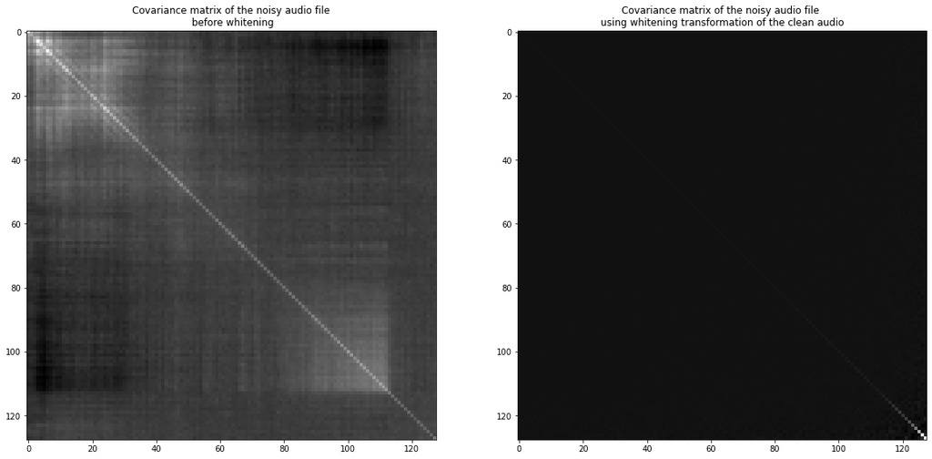

```python
fig=plt.figure(figsize=(20,20))
plot=fig.add_subplot(1,2,1)
plt.imshow(cov_matrix(noisy_audio_feature_vector),cmap='gray')
plot.set_title('Covariance matrix of the noisy audio file\n before whitening')
plot=fig.add_subplot(1,2,2)
plt.imshow(noisy_audio_cov_mat,cmap='gray')
plot.set_title( 'Covariance matrix of the noisy audio file \nusing whitening transformation of the clean audio')
```

The above two plots represent a noisy audio file's co-variance matrix and its whitening transformation(from clean audio whitening transformation).

In the second plot, the diagonal is not visible clearly like the previous.

The average absolute value of the non-digonal entry for noisy audio is 0.025820938343077755.

It is relatively higher than the previous case.

Since we are using the whitening-transformation of the clean audio, noise audio is not whitened properly.

# Whitening tranformation of the noisy audio file

```
avg non digonal_entry of noisy_audio cov_matrix 9.285590908753007e-17
```

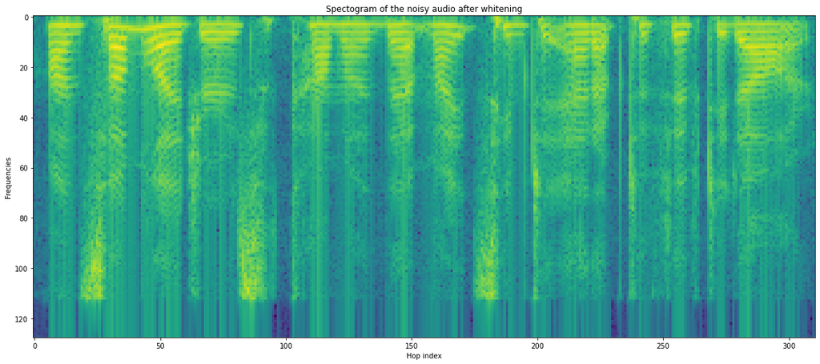

```python
noisy_audio_Y,noisy_audio_L,noisy_audio_U=whitening(noisy_audio_feature_vector)
noisy_audio_cov_mat=(1/N)*noisy_audio_Y.T@noisy_audio_Y
print('avg non digonal_entry of noisy_audio cov_matrix',avg_non_digonal_entry(noisy_audio_cov_mat))

plot_audio_spectrogram(noisy_audio_Y,'Spectogram of the noisy audio after whitening')
# appling that transform on the noise image
```

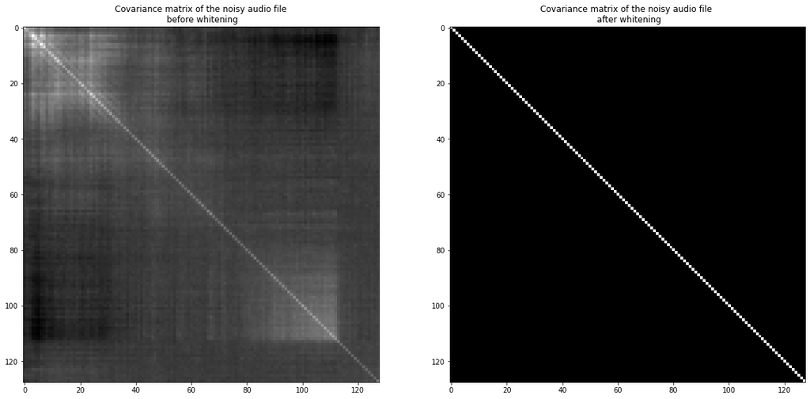

```python
fig=plt.figure(figsize=(20,20))
plot=fig.add_subplot(1,2,1)
plt.imshow(cov_matrix(noisy_audio_feature_vector),cmap='gray')
plot.set_title('Covariance matrix of the noisy audio file\n before whitening')
plot=fig.add_subplot(1,2,2)
plt.imshow(noisy_audio_cov_mat,cmap='gray')
plot.set_title( 'Covariance matrix of the noisy audio file \n after whitening')
```

The above two plots represent the covariance matrices of the noisy audio and its whitening transformation.

We can see the differences between the above two covariance matrix plottings.

After whitening, the covariance matrix of noisy audio is the identity matrix, and all the non-diagonal entries are almost zero.

The average absolute value of the non-diagonal entry for noisy audio is: 9.285590908753007e-17

# we use the whitening tranformation of the noisy audio file to whitening the clean audio

```
we use the whitening tranformation of the noisy audio file to whitening clean audio

avg_non_digonal_entry of clean audio 0.020698494774008806
```

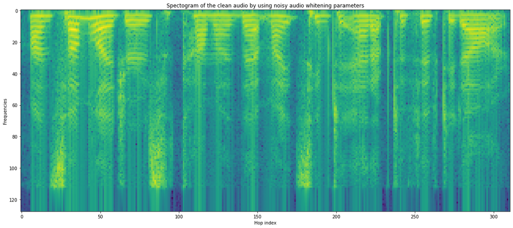

```python
# data centering on noisy data.
clean_audio_centred=clean_audio_feature_vector-np.mean(clean_audio_feature_vector,axis=0)
noisy_audio_L_sqrt=np.diag(np.sqrt(1/noisy_audio_L))
transformed_data=clean_audio_centred@noisy_audio_U
clean_audio_Y=transformed_data@noisy_audio_L_sqrt
clean_audio_cov_mat=(1/N)*clean_audio_Y.T@clean_audio_Y
plot_audio_spectrogram(clean_audio_Y,'Spectogram of the clean audio by using noisy audio whitening parameters')
print("\nwe use the whitening tranformation of the noisy audio file to whitening clean audio \n")
print('avg_non_digonal_entry of clean audio',avg_non_digonal_entry(clean_audio_cov_mat))
```

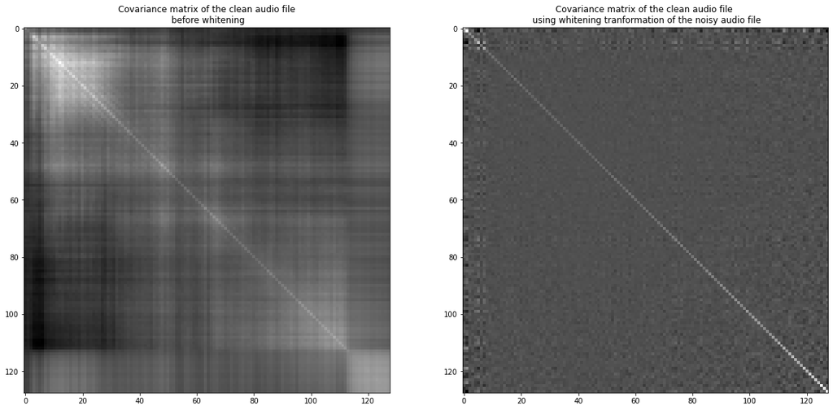

```python
fig=plt.figure(figsize=(20,20))
plot=fig.add_subplot(1,2,1)
plt.imshow(cov_matrix(clean_audio_feature_vector),cmap='gray')
plot.set_title('Covariance matrix of the clean audio file\n before whitening')
plot=fig.add_subplot(1,2,2)
plt.imshow(clean_audio_cov_mat,cmap='gray')
plot.set_title( 'Covariance matrix of the clean audio file \n using whitening tranformation of the noisy audio file')
```

The above two plots represent the clean audio file's covariance matrix and whitening transformation of it (from noisy audio whitening-transformation).

In the second plot, the diagonal elements are not visible as in the previous plot, and non-diagonal's are also not zero (we can observe some black and white spots).

It is relatively higher than the previous case.

Since we are using the whitening-transformation of the noisy audio, clean audio is not appropriately whitened.

*Comment on use of whitenning when the data distribution has changed.*

If you apply a whitening transformation on the same data (on which we are computed the whitening transformation), it performs very well. It means after whitening transformation co-variance matrix will become a proper identity matrix.

But, when using the same whitening transformation on some other data, it is not performing well.

It is neither good at un-correlating the non-diagonal parameters nor making diagonal parameters to unit variance because the transformation parameters(L, U) may be related to the data distribution.

Therefore, when using the same transformation on some other data, it may not work correctly.

We can conclude that whitening transformation of some data distribution may not be the proper choice for some other distribution.